# Neural Ordinary Differential Equations

#### 05/12/2024

Original Paper:

(Chen et al. 2018) https://proceedings.neurips.cc/paper_files/paper/2018/file/69386f6bb1dfed68692a24c8686939b9-Paper.pdf

## Preview

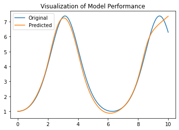

```python
c = 0
t0 = 0
t1 = 10
num_points = 100
z_initial = torch.Tensor([z(0, c)]).to(device)

plt.plot(np.linspace(t0, t1, num_points), [z(t, c).cpu() for t in np.linspace(t0, t1, num_points)], label='Original')
plt.plot(np.linspace(t0, t1, num_points), [model.get_z1(0, t, z_initial).cpu().numpy() for t in tqdm(np.linspace(t0, t1, num_points))], label='Predicted')
plt.title("Visualization of Model Performance")
plt.legend()
```

## Continuous Change of Basis Formula

$L(\mathbf{z}(t_1)) = L[\mathbf{z}(t_0) + \int_{t_0}^{t_1} f(\mathbf{z}(t), t, \theta)dt]$

Let $\mathbf{a}(t) = \frac{\partial L}{\partial \mathbf{z}(t)}$

$\frac{d \mathbf{a}}{dt}(t) = \frac{\partial L}{\partial \mathbf{z}(t_1)} lim_{\epsilon \to 0} \frac{1}{\epsilon} [ \frac{\partial \mathbf{z}(t_1)}{\partial(\mathbf{z}(t + \epsilon))} - \frac{\partial \mathbf{z}(t_1)}{\partial(\mathbf{z}(t))}]$

$ = \frac{\partial L}{\partial \mathbf{z}(t_1)} lim_{\epsilon \to 0} \frac{1}{\epsilon} [ \frac{\partial \mathbf{z}(t_1)}{\partial(\mathbf{z}(t + \epsilon))} - \frac{\partial \mathbf{z}(t_1)}{\partial(\mathbf{z}(t+\epsilon))} \frac{\partial \mathbf{z}(t+\epsilon)}{\partial(\mathbf{z}(t))}]$

$ = \frac{\partial L}{\partial \mathbf{z}(t_1)} lim_{\epsilon \to 0} \frac{\partial \mathbf{z}(t_1)}{\partial(\mathbf{z}(t + \epsilon))} [ \frac{1}{\epsilon}(1 - \frac{\partial \mathbf{z}(t+\epsilon)}{\partial(\mathbf{z}(t))})]$

$ = \frac{\partial L}{\partial \mathbf{z}(t_1)} lim_{\epsilon \to 0} \frac{\partial \mathbf{z}(t_1)}{\partial(\mathbf{z}(t + \epsilon))} [ \frac{1}{\epsilon}(1 - \frac{\partial (\mathbf{z}(t)+\epsilon f(\mathbf{z}(t), t, \theta)))}{\partial(\mathbf{z}(t))})]$

$ = \frac{\partial L}{\partial \mathbf{z}(t_1)} lim_{\epsilon \to 0} \frac{\partial \mathbf{z}(t_1)}{\partial(\mathbf{z}(t + \epsilon))} [ \frac{1}{\epsilon}(1 - \frac{\partial \mathbf{z}(t)}{\partial \mathbf{z}(t)} - \frac{\epsilon \partial (f(\mathbf{z}(t), t, \theta))}{\partial(\mathbf{z}(t))})]$

$ = - \frac{\partial L}{\partial \mathbf{z}(t_1)} lim_{\epsilon \to 0} \frac{\partial \mathbf{z}(t_1)}{\partial(\mathbf{z}(t + \epsilon))} [\frac{ \partial (f(\mathbf{z}(t), t, \theta))}{\partial(\mathbf{z}(t))}]$

$ = - \frac{\partial L}{\partial \mathbf{z}(t_1)} \frac{\partial \mathbf{z}(t_1)}{\partial \mathbf{z}(t)} \frac{ \partial (f(\mathbf{z}(t), t, \theta))}{\partial(\mathbf{z}(t))}$

$ = - \mathbf{a}(t)^T \frac{ \partial (f(\mathbf{z}(t), t, \theta))}{\partial(\mathbf{z}(t))}$

$\frac{\partial L}{\partial \theta} = \int_{t_0}^{t_1} \frac{\partial L}{\partial \mathbf{z}(t)} \frac{\partial \mathbf{z}(t)}{\partial \theta}dt$

$ = \int_{t_1}^{t_0} -\mathbf{a}(t)^T \frac{ \partial f(\mathbf{z}(t), t, \theta)}{\partial(\mathbf{z}(t))} \frac{\partial \mathbf{z}(t)}{\partial \theta}dt$

> $\frac{\partial L}{\partial \theta} = \int_{t_1}^{t_0} -\mathbf{a}(t)^T \frac{ \partial f(\mathbf{z}(t), t, \theta)}{\partial \theta}dt$

## Implementation

which is

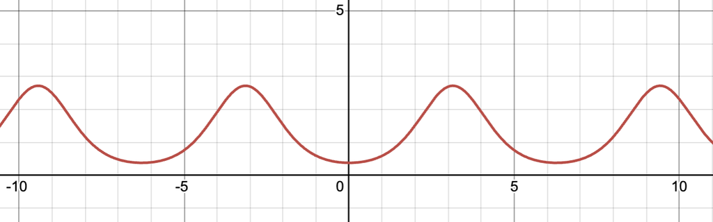

From the Original Paper: (Chen et al. 2018)

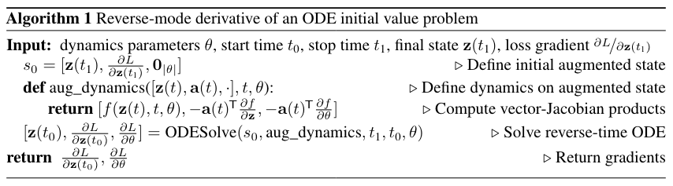

```python
import torch
from torch import nn
import torch.optim
from tqdm import tqdm
from scipy.integrate import solve_ivp, simpson
import warnings
import matplotlib.pyplot as plt
import numpy as np
```

```python
device = torch.device('cpu')
```

```python
def z(t, c):
    if type(t) != torch.Tensor:
        t = torch.Tensor([t]).to(device)
    if not len(t.shape):
        t = t.unsqueeze(axis=0)
    return torch.exp(-torch.cos(t)+1) + c
```

```python
class ODENet(nn.Module):
    def __init__(self):
        super(ODENet, self).__init__()
        with warnings.catch_warnings():
            warnings.filterwarnings("ignore", category=UserWarning)
            self.f = nn.Sequential(
                nn.Linear(2, 50),
                nn.GELU(),
                nn.Linear(50, 75),
                nn.GELU(),
                nn.Linear(75, 1)
            )
        self.loss_fn = nn.MSELoss()
        self.num_parameters = sum([np.prod(x.shape) for x in self.f.parameters()])

    def forward(self, t, z):
        if type(z) != torch.Tensor:
            z = torch.Tensor(z)
        z = z.to(device)
        input_ = torch.cat([z, torch.Tensor([t]).to(device)])
        dz = self.f(input_)
        return dz

    def forward_detached(self, t, z):
        dz = self.forward(t, z).cpu().detach().numpy()
        return dz

    def get_z1(self, t0, t1, z0):
        z0 = z0.cpu().numpy()
        return torch.Tensor(solve_ivp(self.forward_detached, [t0, t1], z0, method='LSODA').y[:,-1]).to(device)

    def loss(self, z1_pred, z1_true):
        return self.loss_fn(z1_pred, z1_true)

    def get_grad_cat(self):
        grad = []
        for layer in self.f:
            if hasattr(layer, 'weight'):
                grad.append(layer.weight.grad.flatten())
                grad.append(layer.bias.grad.flatten())
        return torch.cat(grad)

    def aug(self, t, x):
        self.zero_grad()

        x = torch.Tensor(x).to(device)
        z, a, _ = torch.split(x, [1, 1,x.shape[0]-2])

        z.requires_grad = True
        ft = self.forward(t, z)
        ft.backward()

        partial_f_partial_z = z.grad
        partial_f_partial_theta = self.get_grad_cat()

        da_dt = -a*partial_f_partial_z
        partial_L_partial_theta = -a * partial_f_partial_theta

        return torch.cat([ft, da_dt, partial_L_partial_theta]).cpu().detach().numpy()

    def update_grad(self, t0, t1, z0, true_z1):
        if type(z0) != torch.Tensor:
            z0 = torch.Tensor(z0)

        pred_z1 = self.get_z1(t0, t1, z0)
        pred_z1.requires_grad = True
        loss = self.loss(pred_z1, true_z1)
        loss.backward()
        partial_L_partial_z1 = pred_z1.grad

        pred_z1.requires_grad = False
        partial_L_partial_z1.requires_grad = False
        x1 = torch.cat([pred_z1.cpu(), partial_L_partial_z1.cpu(), torch.zeros(self.num_parameters)])

        x0 = torch.Tensor(solve_ivp(self.aug, [t1, t0], x1, method='LSODA').y[:,-1]).to(device)

        _, _, grad = torch.split(x0, [1, 1,x0.shape[0]-2])

        start_index=0
        for layer in self.f:
            if hasattr(layer, 'weight'):
                n = layer.weight.flatten().shape[0]
                layer.weight.grad = grad[start_index:start_index+n].reshape(layer.weight.grad.shape)
                start_index += n

                n = layer.bias.flatten().shape[0]
                layer.bias.grad = grad[start_index:start_index+n].reshape(layer.bias.grad.shape)
                start_index += n
        return loss.item(), pred_z1
model = ODENet().to(device)
optimizer = torch.optim.Adam(model.parameters())
```

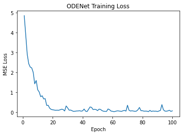

```python
num_epochs = 100
training_loss = []
for epoch in tqdm(range(num_epochs)):
    curr_loss = n = 0
    for t0 in torch.rand(100).to(device):
        t0 *= 10
        t0 -= 1
        t1 = t0 + 1
        c = torch.zeros(1).to(device)
        true_z0 = z(t0, c)
        true_z1 = z(t1, c)

        optimizer.zero_grad()

        curr_loss_, pred_z1 = model.update_grad(t0, t1, true_z0, true_z1)
        curr_loss += curr_loss_
        n += 1
        optimizer.step()
    training_loss.append(curr_loss / n)
#     print(f"Epoch {epoch} Loss: {curr_loss / n}")

plt.plot(np.arange(1, len(training_loss)+1), training_loss)
plt.title('ODENet Training Loss')
plt.ylabel('MSE Loss')
plt.xlabel('Epoch')
```

# Visualizing model performance

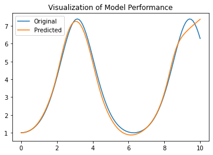

```python
c = 0
t0 = 0
t1 = 10
num_points = 100
z_initial = torch.Tensor([z(0, c)]).to(device)

plt.plot(np.linspace(t0, t1, num_points), [z(t, c).cpu() for t in np.linspace(t0, t1, num_points)], label='Original')
plt.plot(np.linspace(t0, t1, num_points), [model.get_z1(0, t, z_initial).cpu().numpy() for t in tqdm(np.linspace(t0, t1, num_points))], label='Predicted')
plt.title("Visualization of Model Performance")
plt.legend()
```